# Walk & Bike/Micromobility Summary

Published

August 20, 2026

## Trips in Region

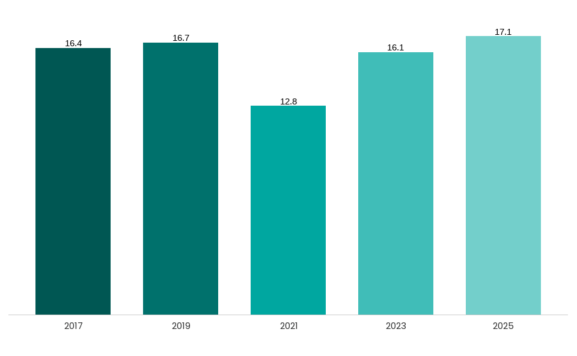

Figure 1: Total Trips in Region

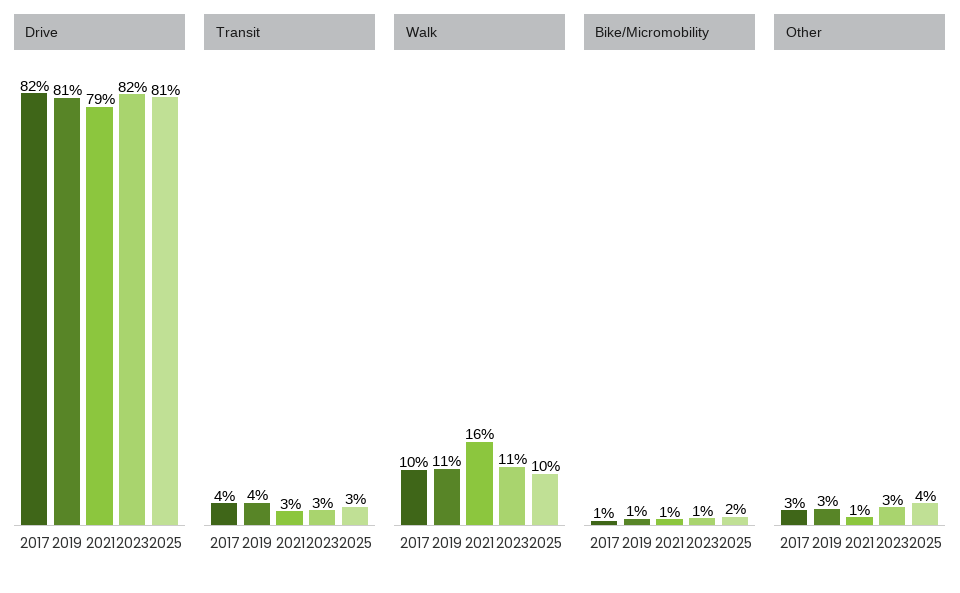

Figure 2: Trips by Mode

## Walking and Bike/Micromobility Trips

- Number and share of walk trips in region is down from 2021
- Number and share of bike/micro trips in region is up from 2021

### Walking

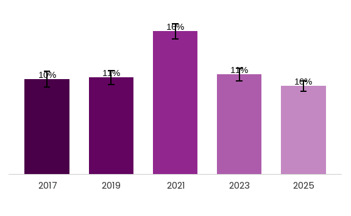

Figure 3: Walk Trips

### Bike/Micromobility

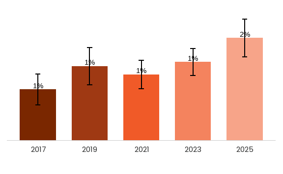

Figure 4: Bike/Micromobility Trips

### Trips by Household Income

- Walk trips in 2025 for $50k-$150k groups are down from pre-COVID levels
- Walk trips in 2025 for $150k+ group are up from pre-COVID
- Bike/micro trips in 2025 for under $50k group are up significantly from all prior years; hard to say anything for other groups

#### Walking

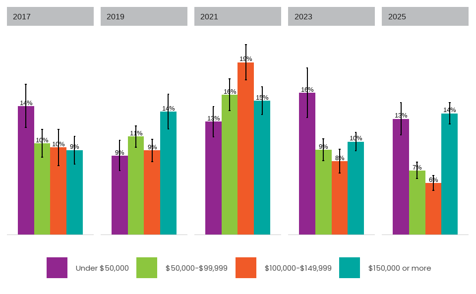

Figure 5: Walk Trips by Income

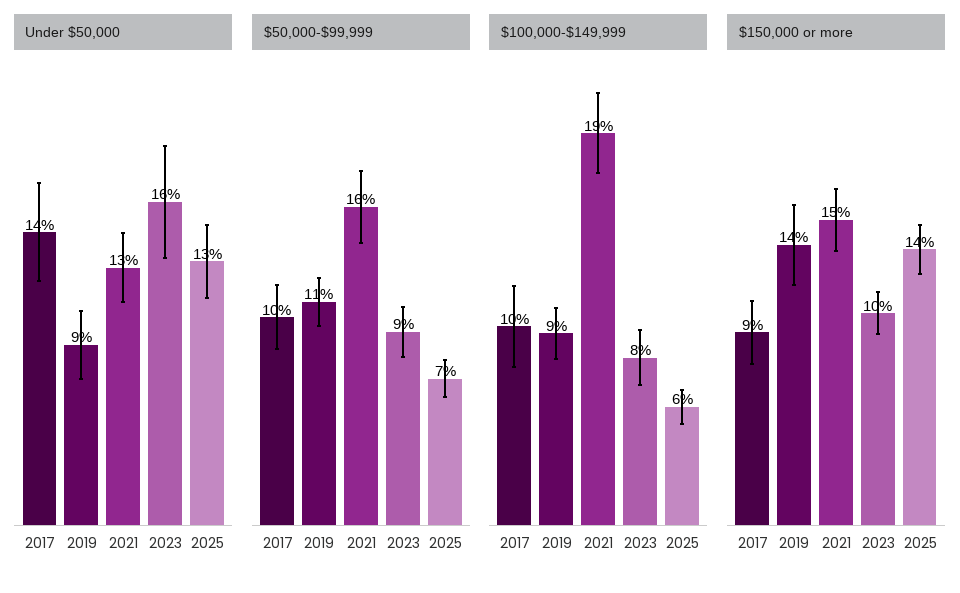

Figure 6: Walk Trips by Income

Table 1

| survey year | hhincome_detailed_combined | mode_class_5 | sample | share | share_moe | estimates |
| --- | --- | --- | --- | --- | --- | --- |
| 2017 | Under $50,000 | Walk | 1,487 | 14.4% | 2.41% | 482,593 |
| 2017 | $50,000-$99,999 | Walk | 1,829 | 10.2% | 1.57% | 473,898 |
| 2017 | $100,000-$149,999 | Walk | 1,354 | 9.7% | 2.01% | 270,713 |
| 2017 | $150,000 or more | Walk | 1,372 | 9.4% | 1.55% | 387,687 |
| 2019 | Under $50,000 | Walk | 1,874 | 8.8% | 1.68% | 315,807 |
| 2019 | $50,000-$99,999 | Walk | 2,509 | 11.0% | 1.18% | 441,057 |
| 2019 | $100,000-$149,999 | Walk | 1,953 | 9.4% | 1.25% | 312,481 |
| 2019 | $150,000 or more | Walk | 2,680 | 13.7% | 1.96% | 593,412 |
| 2021 | Under $50,000 | Walk | 331 | 12.6% | 1.69% | 269,023 |
| 2021 | $50,000-$99,999 | Walk | 398 | 15.6% | 1.76% | 459,376 |
| 2021 | $100,000-$149,999 | Walk | 410 | 19.2% | 1.97% | 477,739 |
| 2021 | $150,000 or more | Walk | 468 | 15.0% | 1.53% | 558,326 |
| 2023 | Under $50,000 | Walk | 1,601 | 15.9% | 2.76% | 430,605 |
| 2023 | $50,000-$99,999 | Walk | 1,629 | 9.5% | 1.22% | 364,953 |
| 2023 | $100,000-$149,999 | Walk | 1,083 | 8.2% | 1.35% | 233,960 |
| 2023 | $150,000 or more | Walk | 1,951 | 10.4% | 1.03% | 533,616 |
| 2025 | Under $50,000 | Walk | 541 | 12.9% | 1.81% | 310,386 |
| 2025 | $50,000-$99,999 | Walk | 764 | 7.2% | 0.90% | 262,212 |
| 2025 | $100,000-$149,999 | Walk | 574 | 5.8% | 0.85% | 171,878 |
| 2025 | $150,000 or more | Walk | 1,423 | 13.5% | 1.20% | 786,062 |

#### Bike/Micromobility

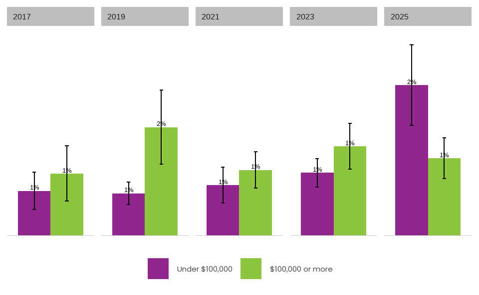

Figure 7: Bike/Micromobility Trips by Income

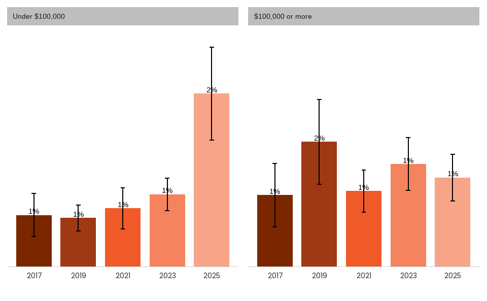

Figure 8: Bike/Micromobility Trips by Income

Table 2

| survey year | hhincome_bin | mode_class_5 | sample | share | share_moe | estimates |
| --- | --- | --- | --- | --- | --- | --- |
| 2017 | Under $100,000 | Bike/Micromobility | 439 | 0.7% | 0.29% | 55,737 |
| 2017 | $100,000 or more | Bike/Micromobility | 326 | 1.0% | 0.43% | 66,504 |
| 2019 | Under $100,000 | Bike/Micromobility | 477 | 0.7% | 0.18% | 50,001 |
| 2019 | $100,000 or more | Bike/Micromobility | 595 | 1.7% | 0.58% | 129,007 |
| 2021 | Under $100,000 | Bike/Micromobility | 63 | 0.8% | 0.28% | 39,951 |
| 2021 | $100,000 or more | Bike/Micromobility | 66 | 1.0% | 0.28% | 63,441 |
| 2023 | Under $100,000 | Bike/Micromobility | 356 | 1.0% | 0.22% | 64,164 |
| 2023 | $100,000 or more | Bike/Micromobility | 494 | 1.4% | 0.36% | 110,857 |
| 2025 | Under $100,000 | Bike/Micromobility | 167 | 2.3% | 0.63% | 141,881 |
| 2025 | $100,000 or more | Bike/Micromobility | 291 | 1.2% | 0.32% | 105,681 |

#### Bike/Micromobility (exp)

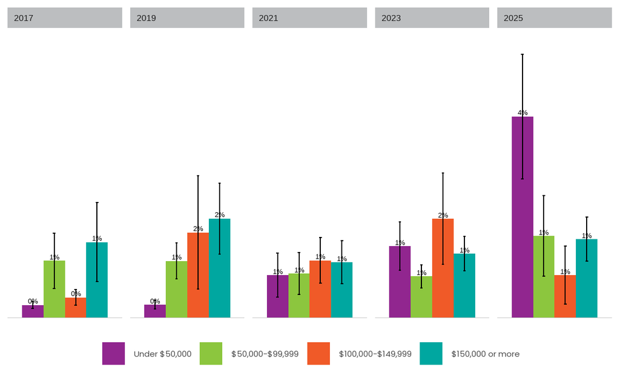

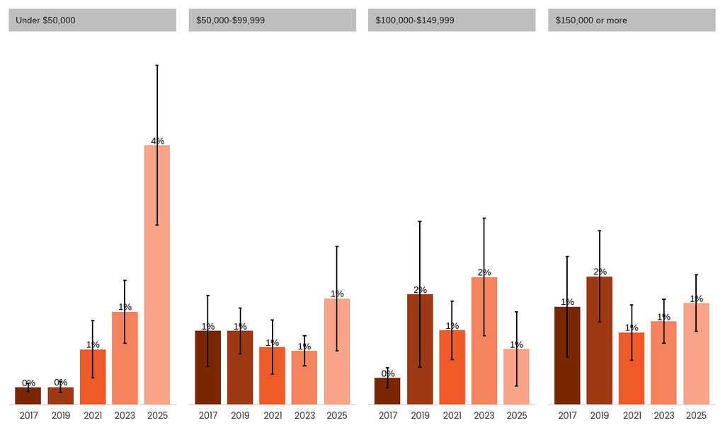

### Trips by Race/Ethnicity

#### Walking (exp)

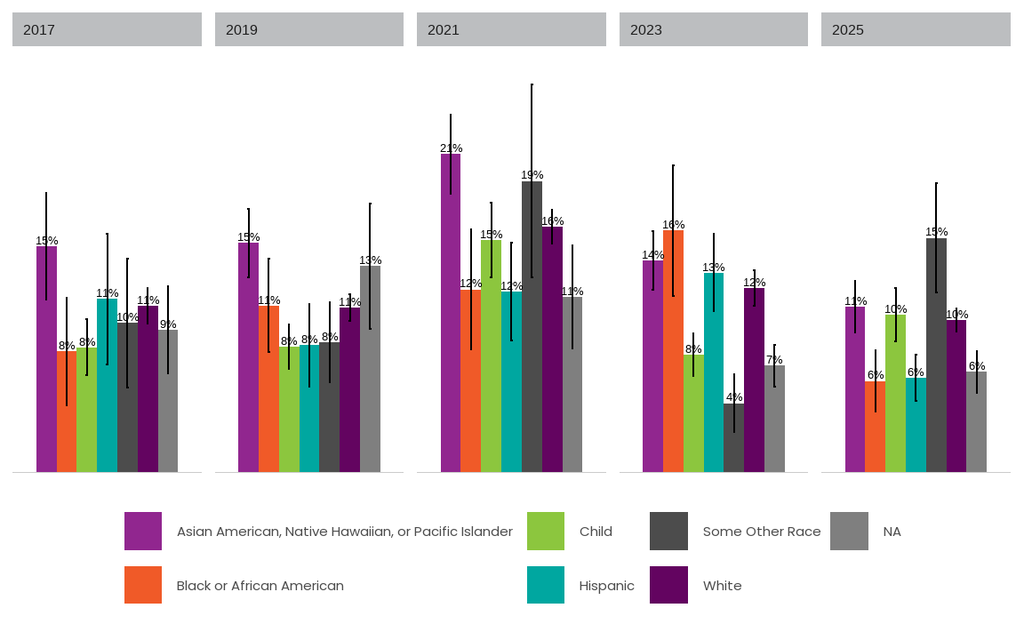

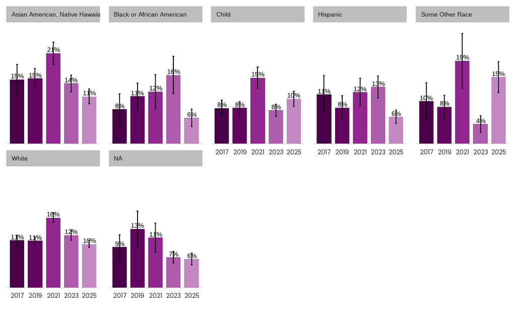

#### Bike/Micromobility (exp)

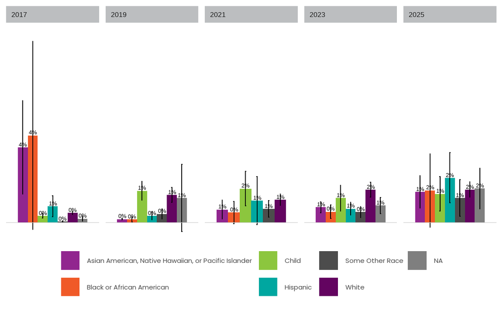

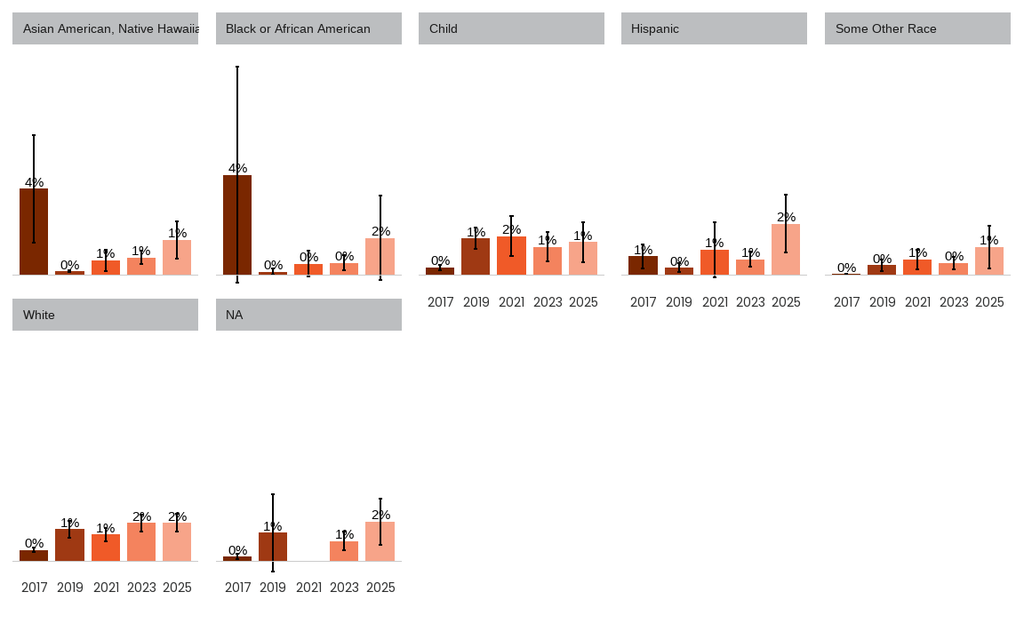

#### Walking

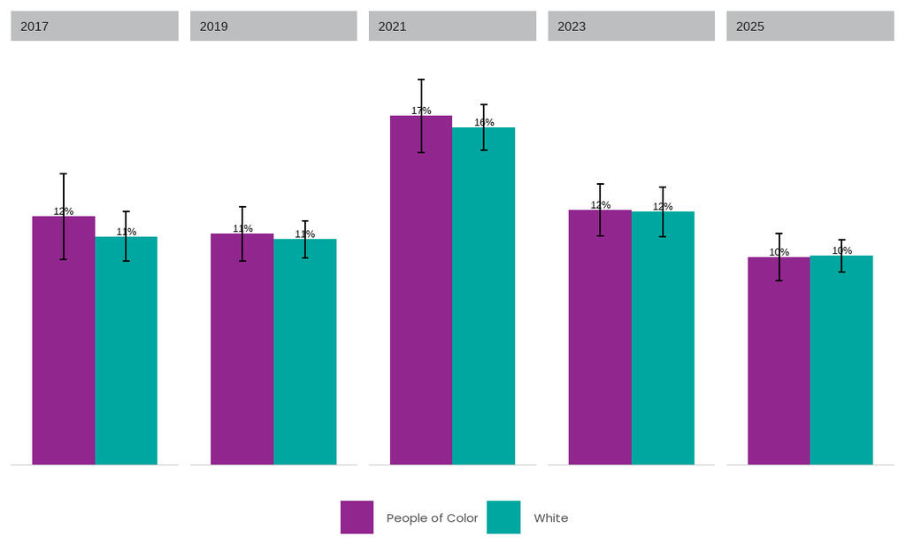

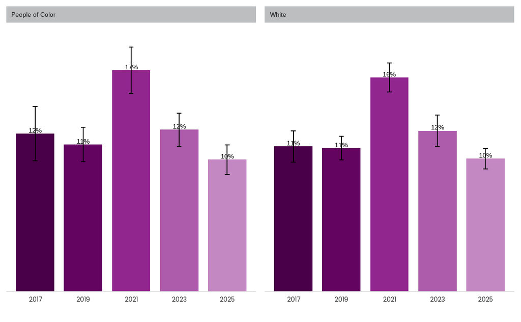

#### Bike/Micromobility

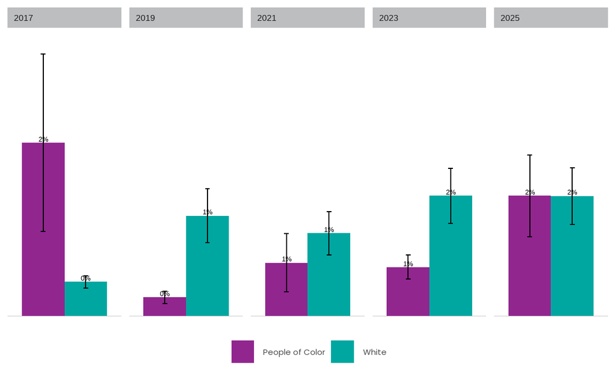

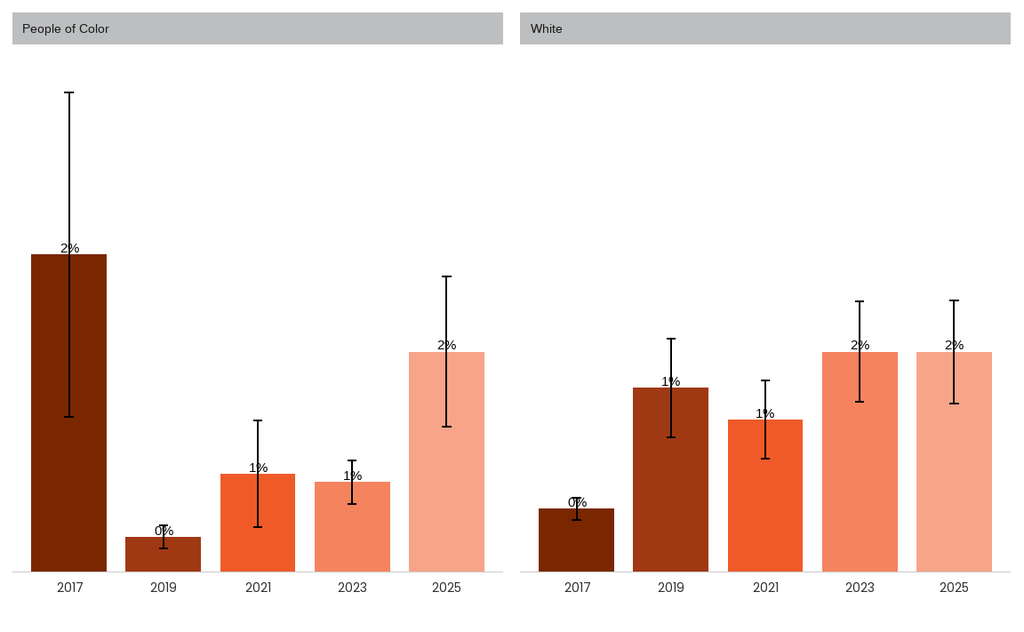

### Trips by Age

- Walk trips up for Under 18 group but down in others
- Large increase in bike/micro for 18-34 group after 2021

#### Walking

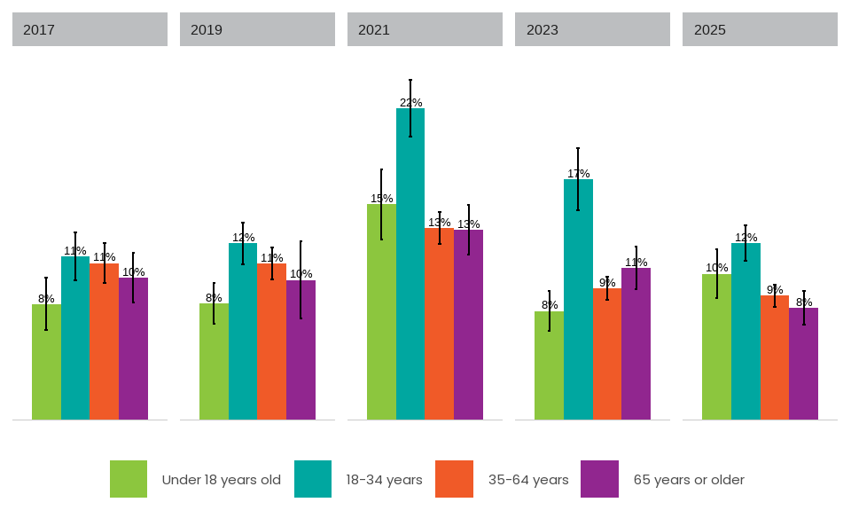

Figure 9: Walk Trips by Age

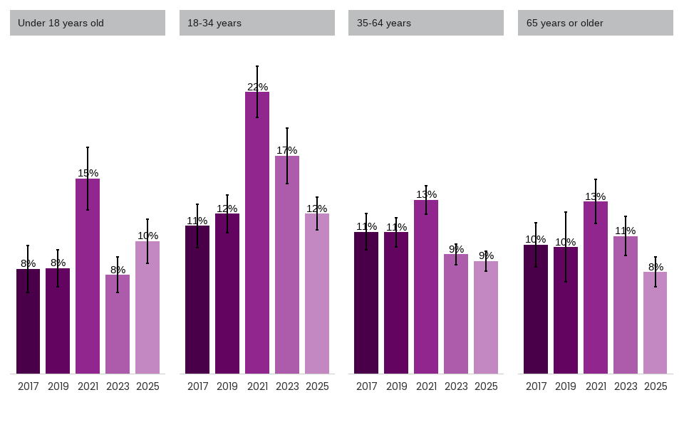

Figure 10: Walk Trips by Age

Table 3

| survey year | age_condensed | mode_class_5 | sample | share | share_moe | estimates |
| --- | --- | --- | --- | --- | --- | --- |
| 2017 | Under 18 years old | Walk | 479 | 8.1% | 1.83% | 218,446 |
| 2017 | 18-34 years | Walk | 2,904 | 11.4% | 1.68% | 386,014 |
| 2017 | 35-64 years | Walk | 2,682 | 11.0% | 1.42% | 859,639 |
| 2017 | 65 years or older | Walk | 685 | 10.0% | 1.73% | 248,449 |
| 2019 | Under 18 years old | Walk | 575 | 8.2% | 1.43% | 226,297 |
| 2019 | 18-34 years | Walk | 4,413 | 12.4% | 1.47% | 464,206 |
| 2019 | 35-64 years | Walk | 3,936 | 10.9% | 1.13% | 873,088 |
| 2019 | 65 years or older | Walk | 812 | 9.8% | 2.70% | 217,833 |
| 2021 | Under 18 years old | Walk | 140 | 15.1% | 2.44% | 210,600 |
| 2021 | 18-34 years | Walk | 550 | 21.8% | 1.99% | 715,688 |
| 2021 | 35-64 years | Walk | 786 | 13.4% | 1.12% | 803,399 |
| 2021 | 65 years or older | Walk | 340 | 13.3% | 1.71% | 290,381 |
| 2023 | Under 18 years old | Walk | 377 | 7.6% | 1.38% | 183,105 |
| 2023 | 18-34 years | Walk | 2,747 | 16.9% | 2.17% | 625,371 |
| 2023 | 35-64 years | Walk | 2,853 | 9.2% | 0.82% | 689,498 |
| 2023 | 65 years or older | Walk | 946 | 10.7% | 1.50% | 270,950 |
| 2025 | Under 18 years old | Walk | 231 | 10.2% | 1.72% | 309,345 |
| 2025 | 18-34 years | Walk | 1,222 | 12.4% | 1.26% | 483,438 |
| 2025 | 35-64 years | Walk | 1,599 | 8.7% | 0.79% | 677,674 |
| 2025 | 65 years or older | Walk | 468 | 7.9% | 1.17% | 187,523 |

#### Bike/Micromobility

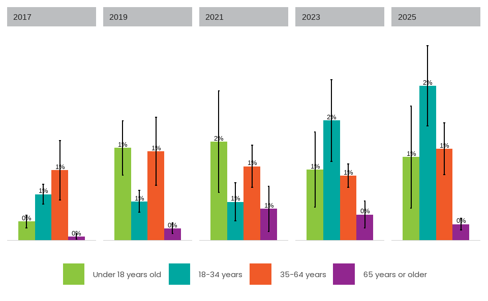

Figure 11: Bike/Micromobility Trips by Age

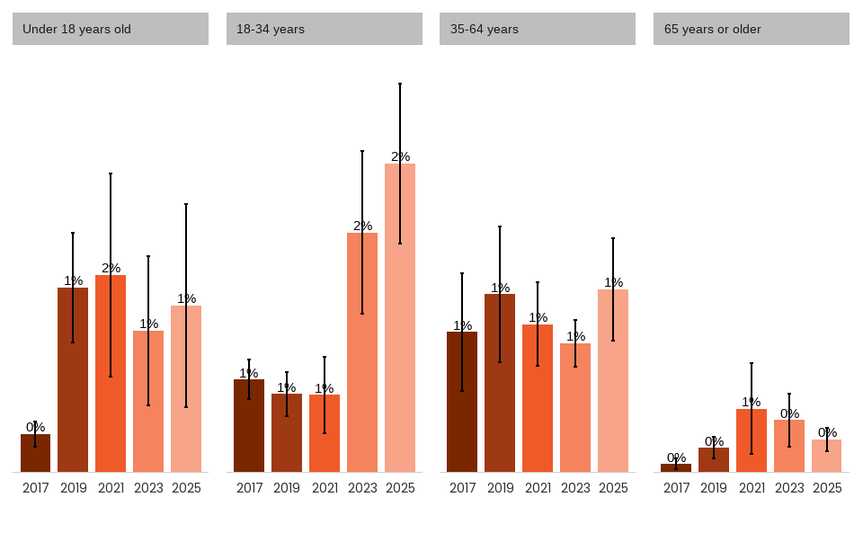

Figure 12: Bike/Micromobility Trips by Age

Table 4

| survey year | age_condensed | mode_class_5 | sample | share | share_moe | estimates |
| --- | --- | --- | --- | --- | --- | --- |
| 2017 | Under 18 years old | Bike/Micromobility | 70 | 0.3% | 0.10% | 8,163 |
| 2017 | 18-34 years | Bike/Micromobility | 379 | 0.7% | 0.16% | 25,048 |
| 2017 | 35-64 years | Bike/Micromobility | 356 | 1.1% | 0.48% | 88,323 |
| 2017 | 65 years or older | Bike/Micromobility | 15 | 0.1% | 0.04% | 1,521 |
| 2019 | Under 18 years old | Bike/Micromobility | 121 | 1.5% | 0.44% | 41,292 |
| 2019 | 18-34 years | Bike/Micromobility | 486 | 0.6% | 0.18% | 23,481 |
| 2019 | 35-64 years | Bike/Micromobility | 499 | 1.4% | 0.55% | 114,520 |
| 2019 | 65 years or older | Bike/Micromobility | 54 | 0.2% | 0.09% | 4,268 |
| 2021 | Under 18 years old | Bike/Micromobility | 21 | 1.6% | 0.82% | 22,191 |
| 2021 | 18-34 years | Bike/Micromobility | 24 | 0.6% | 0.31% | 20,288 |
| 2021 | 35-64 years | Bike/Micromobility | 82 | 1.2% | 0.34% | 71,241 |
| 2021 | 65 years or older | Bike/Micromobility | 10 | 0.5% | 0.37% | 11,077 |
| 2023 | Under 18 years old | Bike/Micromobility | 57 | 1.1% | 0.60% | 27,371 |
| 2023 | 18-34 years | Bike/Micromobility | 380 | 1.9% | 0.66% | 71,580 |
| 2023 | 35-64 years | Bike/Micromobility | 422 | 1.0% | 0.19% | 77,673 |
| 2023 | 65 years or older | Bike/Micromobility | 58 | 0.4% | 0.22% | 10,563 |
| 2025 | Under 18 years old | Bike/Micromobility | 19 | 1.3% | 0.82% | 40,542 |
| 2025 | 18-34 years | Bike/Micromobility | 169 | 2.5% | 0.64% | 97,182 |
| 2025 | 35-64 years | Bike/Micromobility | 249 | 1.5% | 0.41% | 114,940 |
| 2025 | 65 years or older | Bike/Micromobility | 40 | 0.3% | 0.09% | 6,188 |

### Trips by Gender

- Non-binary/Other group appears to walk & bike more than other groups, but small sizes make it hard to say
- Walking trips in 2025 down for men; slight increase for women

#### Walking

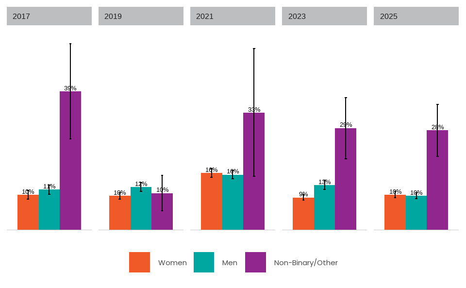

Figure 13: Walk Trips by Gender

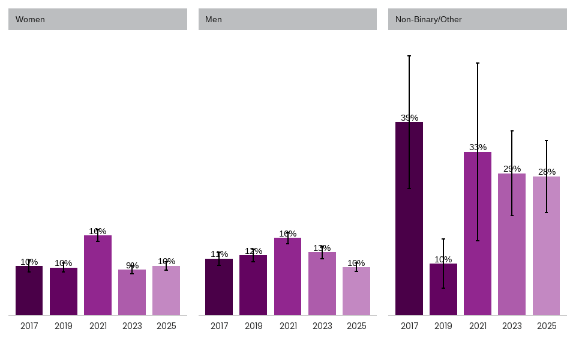

Figure 14: Walk Trips by Gender

#### Bike/Micromobility

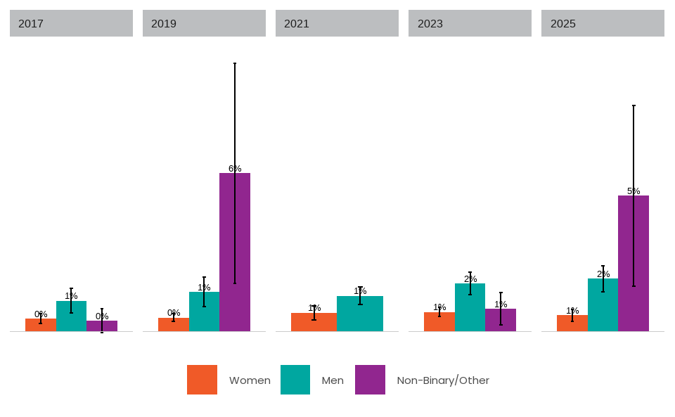

Figure 15: Bike/Micromobility Trips by Gender

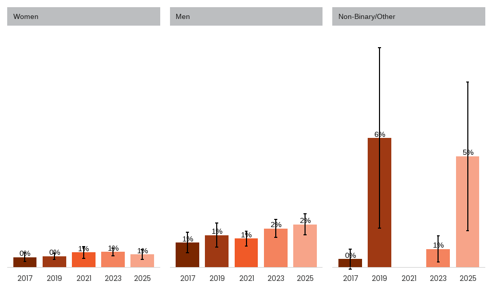

Figure 16: Bike/Micromobility Trips by Gender

### Trips based on Home Location

- Number of walk & bike trips by people living in RGCs is a fraction of trips made by people living outside them, but shares are much higher
- Walk trips for people in RGCs remain elevated after 2021
- Share of bike trips for people in RGCs shows significant growth after 2021

#### Walking

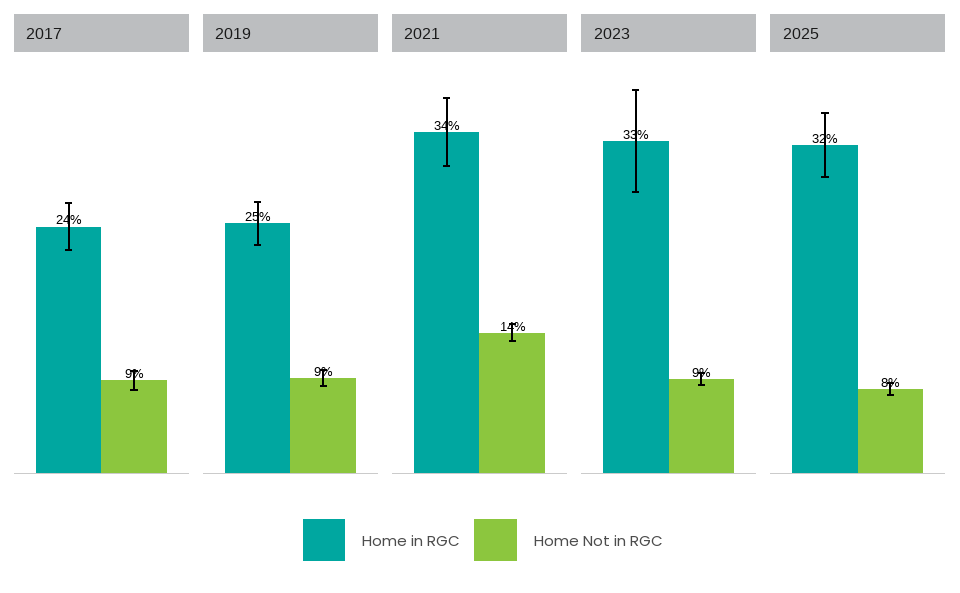

Figure 17: Walk Trips by Home Location

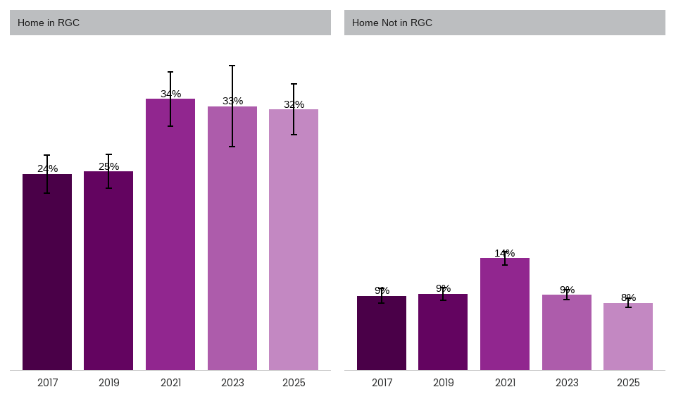

Figure 18: Walk Trips by Home Location

Table 5

| survey year | in_rgc | mode_class_5 | sample | share | share_moe | estimates |
| --- | --- | --- | --- | --- | --- | --- |
| 2017 | Home Not in RGC | Walk | 3,432 | 9.2% | 0.91% | 1,375,527 |
| 2017 | Home in RGC | Walk | 3,318 | 24.3% | 2.34% | 337,022 |
| 2019 | Home Not in RGC | Walk | 4,920 | 9.4% | 0.80% | 1,449,670 |
| 2019 | Home in RGC | Walk | 4,816 | 24.6% | 2.08% | 331,754 |
| 2021 | Home Not in RGC | Walk | 1,407 | 13.8% | 0.84% | 1,607,026 |
| 2021 | Home in RGC | Walk | 409 | 33.7% | 3.36% | 413,042 |
| 2023 | Home Not in RGC | Walk | 4,525 | 9.3% | 0.60% | 1,398,603 |
| 2023 | Home in RGC | Walk | 2,398 | 32.7% | 5.04% | 370,320 |
| 2025 | Home Not in RGC | Walk | 2,662 | 8.3% | 0.57% | 1,339,526 |
| 2025 | Home in RGC | Walk | 858 | 32.4% | 3.18% | 318,454 |

#### Bike/Micromobility

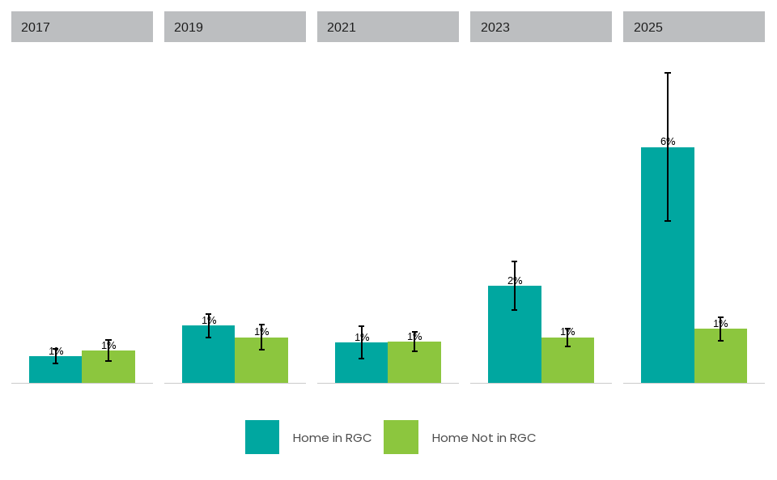

Figure 19: Bike/Micromobility Trips by Home Location

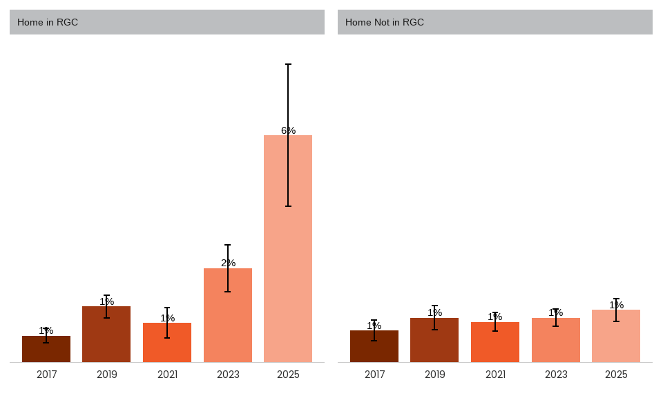

Figure 20: Bike/Micromobility Trips by Home Location

Table 6

| survey year | in_rgc | mode_class_5 | sample | share | share_moe | estimates |
| --- | --- | --- | --- | --- | --- | --- |
| 2017 | Home Not in RGC | Bike/Micromobility | 589 | 0.8% | 0.25% | 114,246 |
| 2017 | Home in RGC | Bike/Micromobility | 231 | 0.6% | 0.17% | 8,809 |
| 2019 | Home Not in RGC | Bike/Micromobility | 827 | 1.1% | 0.30% | 165,401 |
| 2019 | Home in RGC | Bike/Micromobility | 333 | 1.3% | 0.28% | 18,159 |
| 2021 | Home Not in RGC | Bike/Micromobility | 99 | 1.0% | 0.23% | 113,118 |
| 2021 | Home in RGC | Bike/Micromobility | 38 | 1.0% | 0.37% | 11,679 |
| 2023 | Home Not in RGC | Bike/Micromobility | 681 | 1.1% | 0.21% | 161,328 |
| 2023 | Home in RGC | Bike/Micromobility | 236 | 2.3% | 0.57% | 25,858 |
| 2025 | Home Not in RGC | Bike/Micromobility | 353 | 1.3% | 0.28% | 204,393 |
| 2025 | Home in RGC | Bike/Micromobility | 124 | 5.5% | 1.73% | 54,459 |

### Trips by County

- Walk share significantly decreased in Kitsap, Pierce in 2025

#### Walking

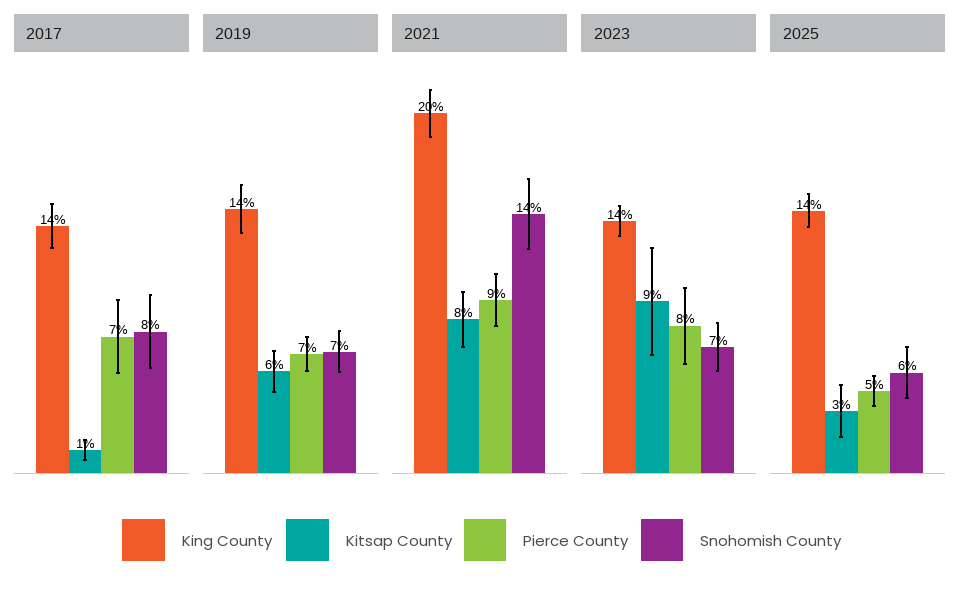

Figure 21: Walk Trips by Home County

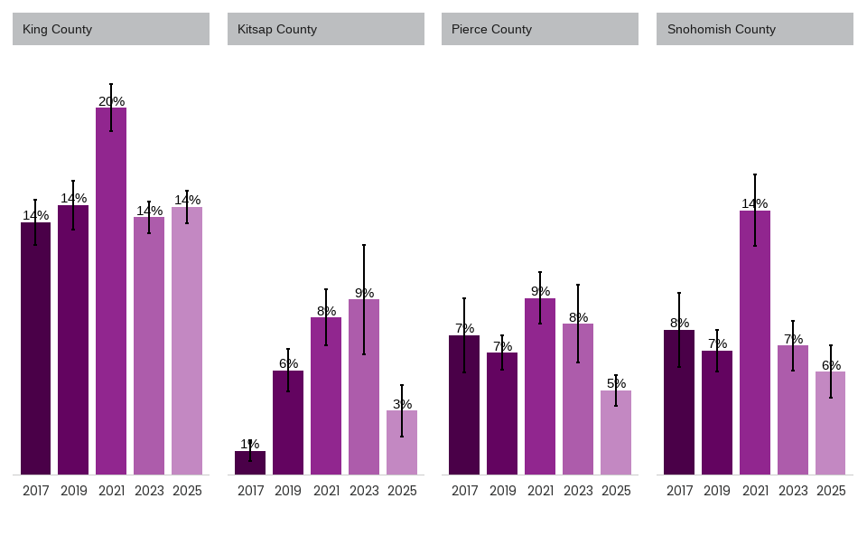

Figure 22: Walk Trips by Home County

Table 7

| survey year | home_county | mode_class_5 | sample | share | share_moe | estimates |
| --- | --- | --- | --- | --- | --- | --- |
| 2017 | King County | Walk | 6,441 | 13.5% | 1.22% | 1,226,734 |
| 2017 | Kitsap County | Walk | 27 | 1.3% | 0.55% | 14,376 |
| 2017 | Pierce County | Walk | 161 | 7.5% | 1.99% | 232,798 |
| 2017 | Snohomish County | Walk | 121 | 7.8% | 1.98% | 238,641 |
| 2019 | King County | Walk | 8,637 | 14.5% | 1.32% | 1,263,182 |
| 2019 | Kitsap County | Walk | 258 | 5.6% | 1.14% | 46,833 |
| 2019 | Pierce County | Walk | 478 | 6.5% | 0.92% | 266,316 |
| 2019 | Snohomish County | Walk | 363 | 6.6% | 1.12% | 205,093 |
| 2021 | King County | Walk | 1,244 | 19.7% | 1.27% | 1,364,765 |
| 2021 | Kitsap County | Walk | 168 | 8.4% | 1.50% | 66,307 |
| 2021 | Pierce County | Walk | 178 | 9.5% | 1.40% | 276,095 |
| 2021 | Snohomish County | Walk | 226 | 14.2% | 1.92% | 312,902 |
| 2023 | King County | Walk | 6,076 | 13.8% | 0.84% | 1,179,502 |
| 2023 | Kitsap County | Walk | 78 | 9.4% | 2.94% | 80,226 |
| 2023 | Pierce County | Walk | 479 | 8.1% | 2.09% | 302,029 |
| 2023 | Snohomish County | Walk | 290 | 6.9% | 1.33% | 207,167 |
| 2025 | King County | Walk | 2,552 | 14.4% | 0.89% | 1,261,596 |
| 2025 | Kitsap County | Walk | 104 | 3.4% | 1.40% | 35,166 |
| 2025 | Pierce County | Walk | 574 | 4.5% | 0.81% | 179,576 |
| 2025 | Snohomish County | Walk | 290 | 5.5% | 1.40% | 181,642 |